# Pstat 131 Final Project: Predicting IPO First-Day “Pops”

Andy

2026-09-14

# Introduction

## Background

For my project I choose to pick whether an initial public offering (IPO) will “pop”. An IPO is the first time a private company sells shares of stock to the public on an open exchange like the NASDAQ. Before the trading begins, the company and the investment banks that manage the offering agree on an offer price which is the price at which shares are offered to investors before the stock starts trading. Once the offering opens the stock up to the public, the price often moves quickly away from that offer price. When a stock’s price jumps above its offer price on its first day of trading, it has “popped” and financial investors refer to this as IPO underpricing: the company effectively sold its shares for less than the market was immediately willing to pay for them. When the stock instead trades the same price or falls below its offer price it means the IPO was valued properly or overvalued.

Predicting whether an IPO will pop is a common question in financial economics. Previous research has linked underpricing to factors like the company’s industry sector, the general condition of the stock market leading up to the offering, and things like company age and size. For this project I will build a supervised classification model that uses only information that would have been known before or at the moment a company’s shares begin trading like sector, company age, employee count, whether the company is U.S.-based, and how the market had been trending in the months before the IPO to predict a binary outcome of whether the stock “pop” on its first day of trading or not?

## Why this project

I choose this project because it recently aligns with my internship of financial data analyst were I was analyzing market data for an insurance company that insures broker-dealers. Broker-Dealers are companies that help investors buy and sell stocks basically like a middleman for example Robinhood or Webull. Seeing whether IPO’s would “pop” or not was interesting to me because usually when an IPO is offered it is offered trough an Investment Banker like Morgan Stanley but with the new stock market you could buy it through these middleman like Robinhood. I found this to be a useful project idea since it is such a new topic and finding out if IPO’s would “pop” would be beneficial information for these insurance companies since there is more risk now that these middlemen can sell IPO’s.

## Project roadmap

The rest of this report follows the basic ML pipeline. First I load and clean the raw IPO data and make the binary response variable `pop`. Then I look at the data visually to understand the outcome and relationship to the candidate predictors. I then split the data into training and testing sets and set up stratified k-fold cross-validation on the training set. Nexy fitting and tuneing the five different types of classification models using the same recipe and the same folds. I will then choose the best-performing model based on cross-validated ROC AUC, fit it to the full training set, and look at its performance one time on the held-out testing set.

# Data

## Source and citation

**Source:** “Stocks IPO information & results,” Kaggle dataset by user `proselotis`. Available at: https://www.kaggle.com/datasets/proselotis/financial-ipo-data

**Citation:** Proselotis. (2020). *Stocks IPO information & results* [Data set]. Kaggle. https://www.kaggle.com/datasets/proselotis/financial-ipo-data

The raw file (`IPODataFull.csv`) contains 3,762 U.S. IPOs listed between 1996 and 2018 which has one row per company. For each IPO it includes the company’s sector/industry classification, basic firm characteristics (employee count, founding year, CEO/president information), the broader market’s trend in the months leading up to the listing, and daily open/high/low/close/volume trading prices for around 260 trading days following the IPO also alongside several outcome measures the original author had already made. The raw file is extremely wide because it includes a full day-by-day price history and a large block of line-item financial-statement data for the fiscal year before each company’s IPO so I will only keep the small subset of columns relevant to my project.

## Loading the raw data

```r
library(tidyverse)
library(tidymodels)
library(janitor)
library(corrplot)
library(discrim)
library(vip)
library(kknn)
library(themis)
library(doParallel)
tidymodels_prefer()
```

```r
ipo_raw <- read_csv("data/IPODataFull.csv", locale = locale(encoding = "latin1")) %>%
  clean_names()   # snake_case everything, same as in Homework 5

dim(ipo_raw)
```

```
## [1] 3762 1664
```

The `clean_names()` function from `janitor` turns every column name into `snake_case` so I don’t have to remember the exact capitalization later. The file is saved in a Latin-1 encoding instead of UTF-8 because some of the company names have special characters in them, so I have to tell `read_csv()` that or it throws parsing errors. Knitting this chunk also gives a “one or more parsing issues” warning. I checked it with `problems()` and all of the flagged cells are in the giant block of per-industry, pre-IPO financial columns (like a column that’s supposed to be a boolean flag but sometimes has an actual dollar amount in it instead). I don’t use any of those columns in the next step, so this warning is safe to ignore for this project.

## Selecting and cleaning the variables I need

Out of the ~1,660 raw columns, two of them give me exactly the response variable I need `open_day0` and `close_day0`. When I looked closely at the raw file I noticed `open_day0` actually acts like the **IPO offer price** instead of the first price that actually got traded. For a lot of rows the day’s low is actually above `open_day0`, which can only happen if the stock started trading above its offer price right away and never came back down to it. `close_day0` is just the stock’s closing price at the end of its first day of trading. Offer price compared to first-day close is actually a pretty standard way IPO underpricing gets measured in finance research whcih works out well for this project.

For the predictors, I picked variables that describe the company and the market conditions of the IPO, and I left out a few of the raw columns `market_cap`, `last_sale`, `revenue`, `net_income`, and the raw `employees` count because they turned out to be snapshots of the company from whenever the dataset was taken in 2020 instead of from the actual IPO date. Using those would leak information about the company’s future into the model.

```r
ipo <- ipo_raw %>%
  transmute(
    symbol             = symbol,
    ipo_year           = year,
    sector             = sector,
    usa_company        = usa_company,
    employees_grouped  = employees_grouped,
    year_difference    = year_difference,     # company age (yrs) at IPO
    ceo_gender         = usable_ceo_gender,
    market_month_trend  = market_month_trend,   # market return, 1 month before IPO
    market_3month_trend = market3month_trend,   # market return, 3 months before IPO
    market_6month_trend = market6month_trend,   # market return, 6 months before IPO
    market_year_trend   = market_year_trend,    # market return, 1 year before IPO
    offer_price        = open_day0,
    close_day0         = close_day0
  ) %>%
  mutate(
    employees_grouped = employees_grouped %>% replace_na("Unknown") %>%
      na_if("Blank") %>% replace_na("Unknown"),
    ceo_gender = ceo_gender %>% replace_na("Unknown") %>%
      recode("Blank" = "Unknown", "unknown" = "Unknown", "andy" = "Unknown"),
    usa_company = usa_company %>% replace_na("Unknown"),
    pct_change = (close_day0 - offer_price) / offer_price
  ) %>%
  filter(!is.na(offer_price), !is.na(close_day0), offer_price > 0) %>%
  mutate(
    sector = str_replace_all(sector, "[^A-Za-z0-9]+", "_"),
    employees_grouped = str_replace_all(employees_grouped, "[^A-Za-z0-9]+", "_")
  ) %>%
  mutate(across(c(sector, usa_company, employees_grouped, ceo_gender), as.factor))

glimpse(ipo)
```

```
## Rows: 3,559
## Columns: 14
## $ symbol              <chr> "A", "AAC", "AAOI", "AAP", "AAT", "AAV", "AAWW", "…
## $ ipo_year            <dbl> 1999, 2014, 2013, 2001, 2011, 2001, 2004, 2010, 19…
## $ sector              <fct> Capital_Goods, Health_Care, Technology, Consumer_S…
## $ usa_company         <fct> Yes, Yes, Yes, Yes, Yes, No, Yes, No, No, Yes, Yes…
## $ employees_grouped   <fct> _10000, 1001_5000, 1001_5000, _10000, 101_500, 0_1…
## $ year_difference     <dbl> 0, 0, 16, 72, 1, 4, 11, 5, 11, -1, 0, NA, 24, -9, …
## $ ceo_gender          <fct> Unknown, male, Unknown, Unknown, Unknown, Unknown,…
## $ market_month_trend  <dbl> 1.60116475, -2.45264501, 0.76173243, 0.61355031, 1…
## $ market_3month_trend <dbl> 2.352507596, -1.194497793, 0.926397583, 1.15371553…
## $ market_6month_trend <dbl> 2.3129743, 0.1385360, 1.2861653, -0.1281101, 1.813…
## $ market_year_trend   <dbl> 2.03984391, 0.88183949, 1.44367154, -0.74590611, 2…
## $ offer_price         <dbl> 27.3725, 17.6000, 9.3700, 13.3833, 21.1800, 8.0800…
## $ close_day0          <dbl> 28.6358, 18.5000, 9.9600, 13.9000, 21.2500, 8.0800…
## $ pct_change          <dbl> 0.046152160, 0.051136364, 0.062966916, 0.038607817…
```

# Exploratory Data Analysis

## Missing data

```r
missing_summary <- ipo %>%
  summarise(across(everything(), ~ sum(is.na(.)))) %>%
  pivot_longer(everything(), names_to = "variable", values_to = "n_missing") %>%
  mutate(pct_missing = n_missing / nrow(ipo)) %>%
  filter(n_missing > 0) %>%
  arrange(desc(n_missing))

missing_summary
```

```
## # A tibble: 2 × 3
##   variable        n_missing pct_missing
##   <chr>               <int>       <dbl>
## 1 year_difference       553       0.155
## 2 sector                538       0.151
```

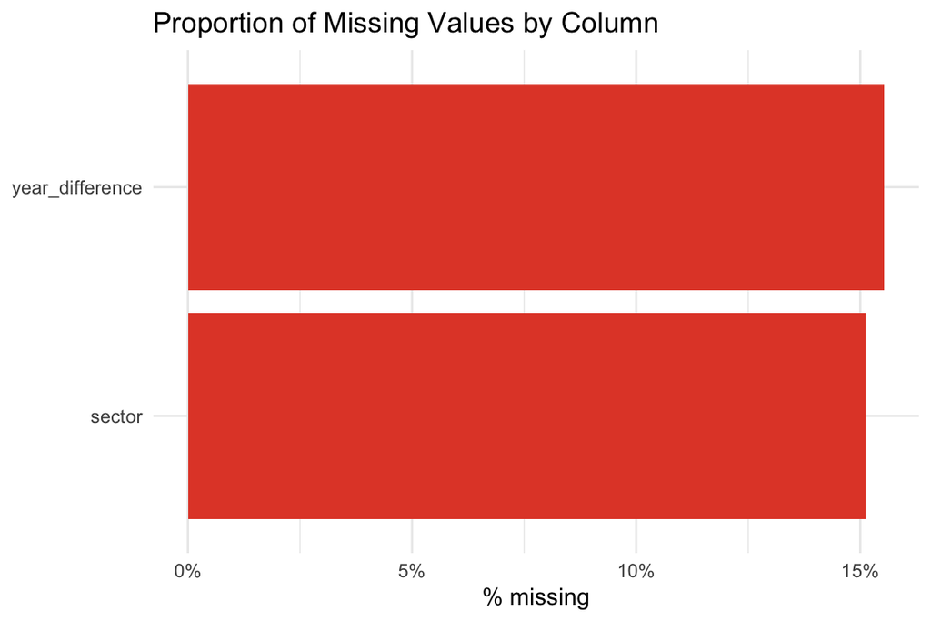

```r
ggplot(missing_summary, aes(x = fct_reorder(variable, pct_missing), y = pct_missing)) +
  geom_col(fill = "#e34a33") +
  coord_flip() +
  scale_y_continuous(labels = scales::percent) +
  labs(title = "Proportion of Missing Values by Column",
       x = NULL, y = "% missing") +
  theme_minimal()
```

## Defining “pop”

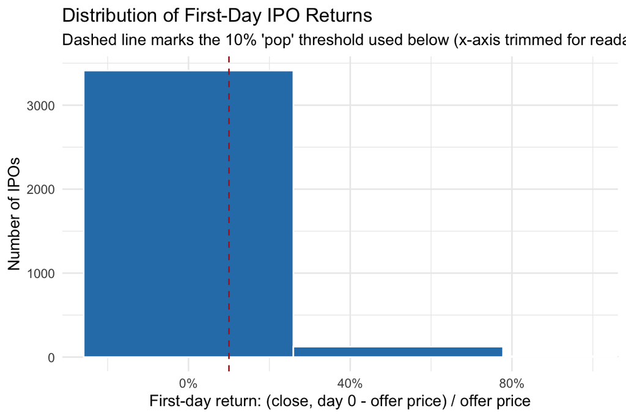

```r
ggplot(ipo, aes(x = pct_change)) +
  geom_histogram(bins = 60, fill = "#2c7fb8", color = "white") +
  geom_vline(xintercept = 0.10, linetype = "dashed", color = "firebrick") +
  coord_cartesian(xlim = c(-0.25, 1)) +
  scale_x_continuous(labels = scales::percent) +
  labs(title = "Distribution of First-Day IPO Returns",
       subtitle = "Dashed line marks the 10% 'pop' threshold used below (x-axis trimmed for readability)",
       x = "First-day return: (close, day 0 - offer price) / offer price",
       y = "Number of IPOs") +
  theme_minimal()
```

```r
quantile(ipo$pct_change, probs = c(0.5, 0.75, 0.9, 0.95, 0.99), na.rm = TRUE)
```

```
##        50%        75%        90%        95%        99%
## 0.01973001 0.05981807 0.14126763 0.23112597 0.59263492
```

The distribution of first-day returns is really right-skewed. The median IPO in this dataset only gains about 2% on its first day wuth the top 10% gaining 14% or more and a handful of low-priced IPOs gaining several hundred percent. I decided to define an IPO as having “popped” if its first-day return is over 10%, which is a threshold that roughly separates the top ~15% of IPOs from the rest. This is also consistent with the underpricing thresholds I saw used in typical financial data I read for my data memo.

```r
ipo <- ipo %>%
  mutate(pop = if_else(pct_change > 0.10, "Pop", "No_Pop")) %>%
  mutate(pop = factor(pop, levels = c("Pop", "No_Pop")))

ipo %>% count(pop) %>% mutate(prop = n / sum(n))
```

```
## # A tibble: 2 × 3
##   pop        n  prop
##   <fct>  <int> <dbl>
## 1 Pop      549 0.154
## 2 No_Pop  3010 0.846
```

As I expected a stock “popping” is the minority class at only around 15% of IPOs. This confirms the class-imbalance risk I flagged in my data memo, which is why I stratify every split and every resampling fold on `pop` below. This is also why I mainly used ROC AUC instead of accuracy since ROC AUC is a lot less sensitive to class imbalance.

## Pop rate by sector

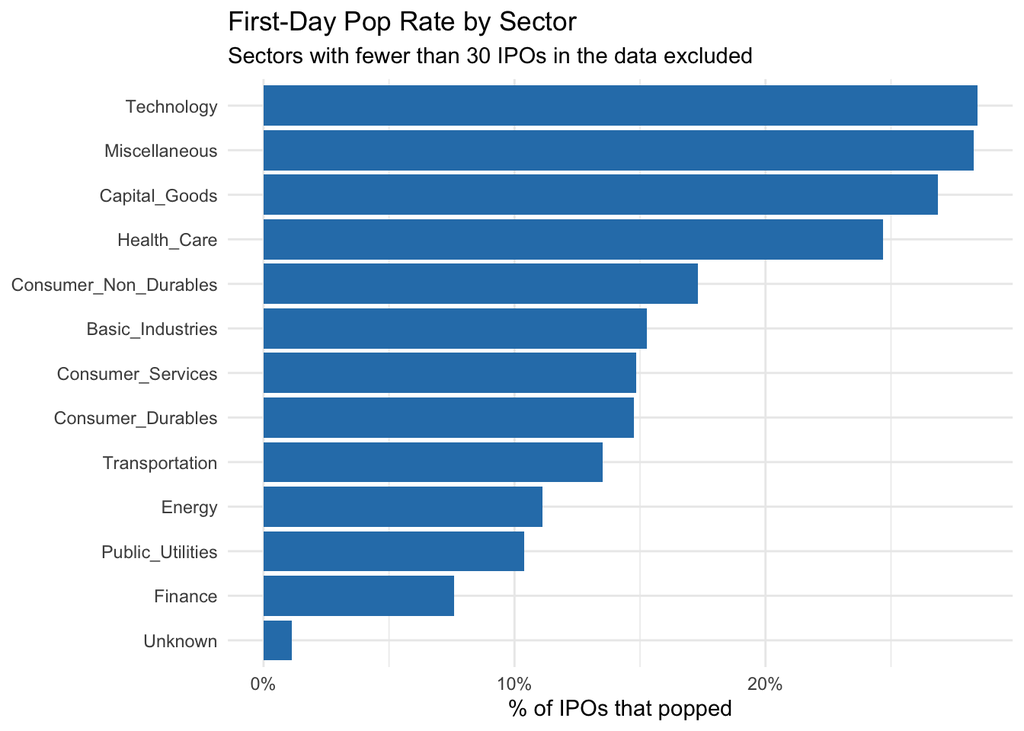

```r
ipo %>%
  mutate(sector = fct_na_value_to_level(sector, "Unknown")) %>%
  group_by(sector) %>%
  filter(n() >= 30) %>%   # only show sectors with a reasonable sample size
  summarise(pop_rate = mean(pop == "Pop"), n = n()) %>%
  ggplot(aes(x = fct_reorder(sector, pop_rate), y = pop_rate)) +
  geom_col(fill = "#2c7fb8") +
  coord_flip() +
  scale_y_continuous(labels = scales::percent) +
  labs(title = "First-Day Pop Rate by Sector",
       subtitle = "Sectors with fewer than 30 IPOs in the data excluded",
       x = NULL, y = "% of IPOs that popped") +
  theme_minimal()
```

There’s real spread between sectors here. Technology and Miscellaneous IPOs pop about 28% of the time when compared to only about 8% for Finance and 10% for Public Utilities. This lines up with the “hot sector” idea from the finance data and makes `sector` an actually useful signal for the model.

## Company age and employee count vs. outcome

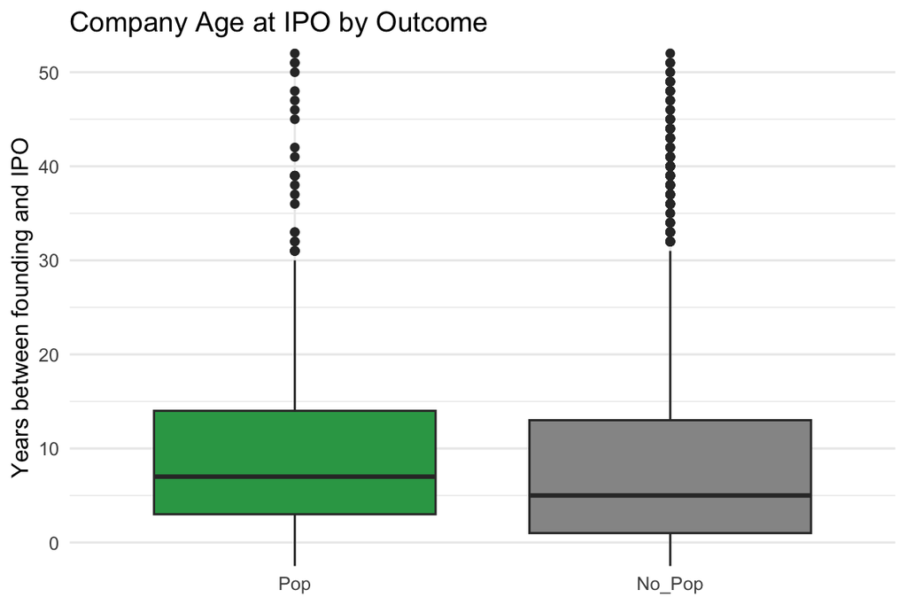

```r
ggplot(ipo, aes(x = pop, y = year_difference, fill = pop)) +
  geom_boxplot() +
  coord_cartesian(ylim = c(0, 50)) +
  scale_fill_manual(values = c("Pop" = "#31a354", "No_Pop" = "#969696")) +
  labs(title = "Company Age at IPO by Outcome",
       x = NULL, y = "Years between founding and IPO") +
  theme_minimal() +
  theme(legend.position = "none")
```

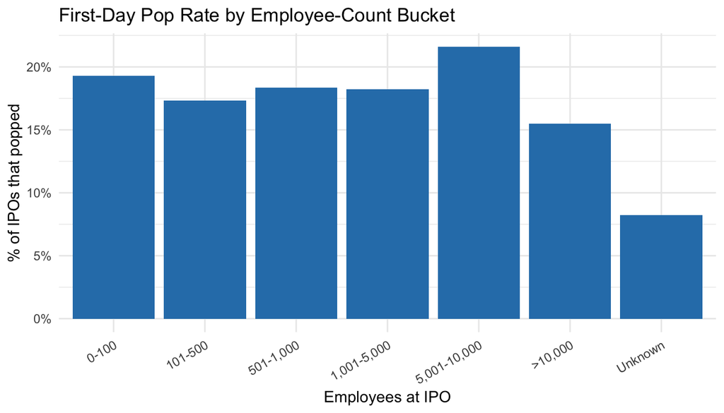

```r
ipo %>%
  mutate(employees_grouped = fct_relevel(employees_grouped,
           "0_100", "101_500", "501_1000", "1001_5000",
           "5001_10000", "_10000", "Unknown")) %>%
  mutate(employees_grouped = fct_recode(employees_grouped,
           "0-100" = "0_100", "101-500" = "101_500", "501-1,000" = "501_1000",
           "1,001-5,000" = "1001_5000", "5,001-10,000" = "5001_10000",
           ">10,000" = "_10000")) %>%
  group_by(employees_grouped) %>%
  summarise(pop_rate = mean(pop == "Pop"), n = n()) %>%
  ggplot(aes(x = employees_grouped, y = pop_rate)) +
  geom_col(fill = "#2c7fb8") +
  scale_y_continuous(labels = scales::percent) +
  labs(title = "First-Day Pop Rate by Employee-Count Bucket",
       x = "Employees at IPO", y = "% of IPOs that popped") +
  theme_minimal() +
  theme(axis.text.x = element_text(angle = 30, hjust = 1))
```

The relationship with company age ends up being pretty mixed instead of clean. The median company that popped was actually a little bit older at IPO of being 7 years old than one that didn’t pop around 5 years old, even though the mean age is actually lower for the ones that popped once you average in a handful of really old companies. Employee count is similarly messy since mid-sized companies which had 5,001-10,000 employees pop the most unlike the smallest ones that i though would. Neither of these variables shows a clean pattern I was expecting which I thought was actually useful finding on its own. It suggests firm size and age by themselves are pretty weak predictors, and whatever signal they do carry probably comes from how the model combines them with sector and market conditions instead of from either variable alone.

## Pop rate by IPO year and market trend

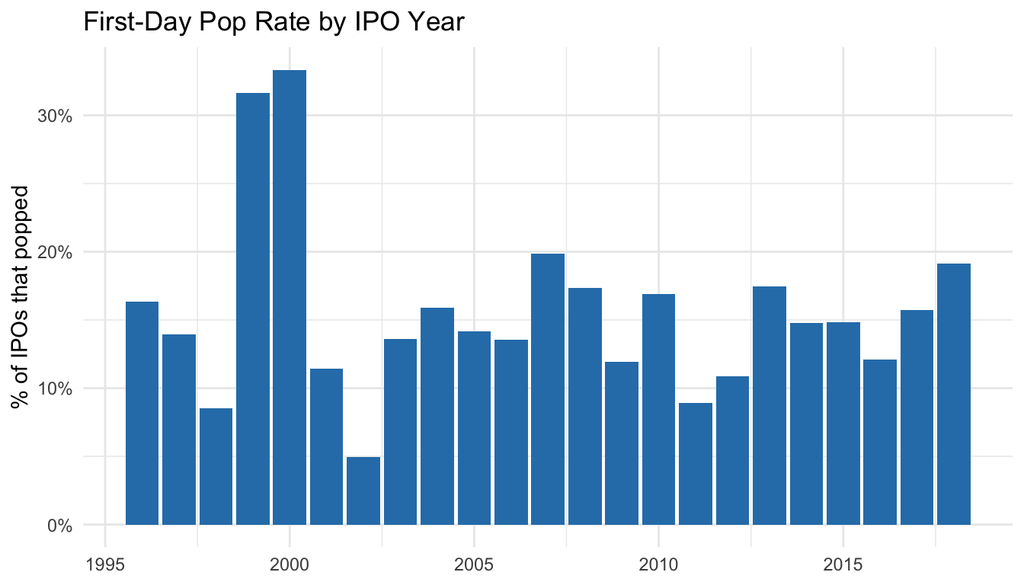

```r
ipo %>%
  group_by(ipo_year) %>%
  summarise(pop_rate = mean(pop == "Pop"), n = n()) %>%
  ggplot(aes(x = ipo_year, y = pop_rate)) +
  geom_col(fill = "#2c7fb8") +
  scale_y_continuous(labels = scales::percent) +
  labs(title = "First-Day Pop Rate by IPO Year",
       x = NULL, y = "% of IPOs that popped") +
  theme_minimal()
```

## Correlation among numeric predictors

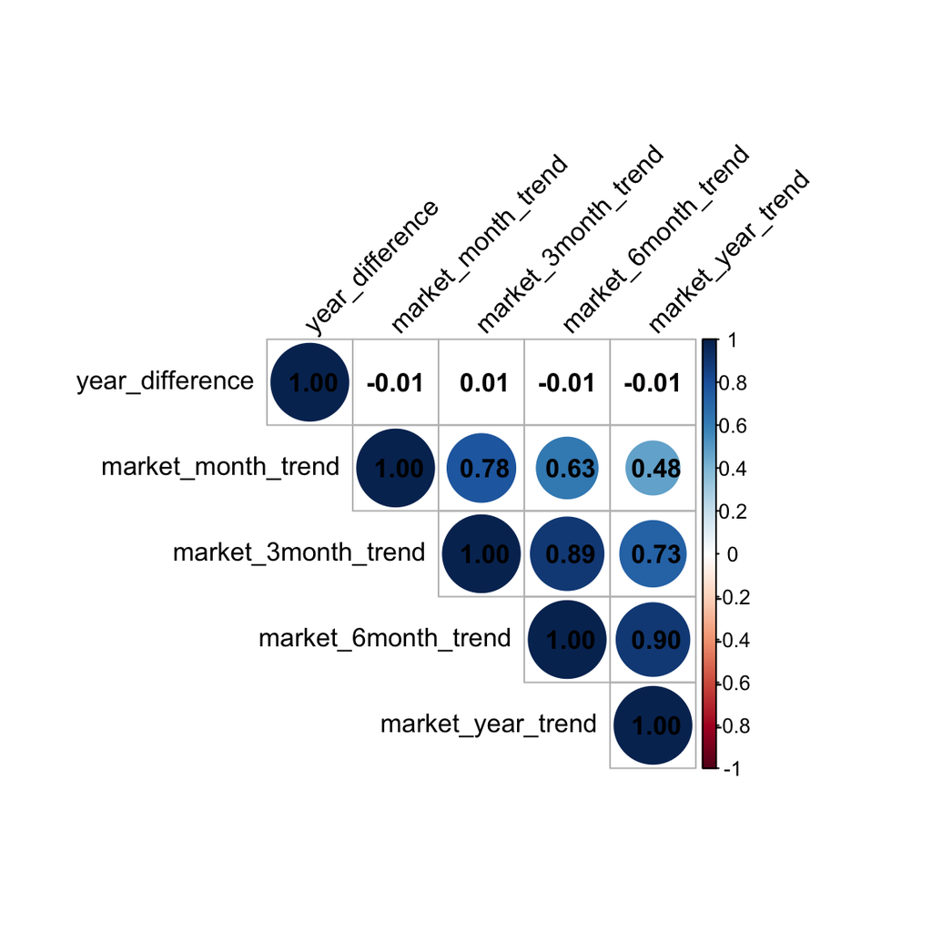

```r
ipo_num <- ipo %>%
  select(year_difference, market_month_trend, market_3month_trend,
         market_6month_trend, market_year_trend) %>%
  drop_na()

corrplot(cor(ipo_num), method = "circle", type = "upper",
          tl.col = "black", tl.srt = 45, addCoef.col = "black")
```

The four market-trend variables are fairly strongly correlated with each other. Correlations range from about 0.48 (1-month vs. 1-year trend) all the way up to 0.90 (6-month vs. 1-year trend), which makes sense because a market that was trending up over the past month usually also trends up over the past year. `year_difference` on the other hand is basically uncorrelated with all four of them with every correlation under 0.02. None of these correlations are strong enough that I’m worried about multicollinearity messing up the linear models below.

# Data Splitting and Cross-Validation

Before I fit any models I split the cleaned data into a **training set** and a **testing set**. The training set gets used for everything up through model selection. I use an 80/20 split that is **stratified** on the outcome variable `pop`. Since “popping” is a fairly rare outcome at about 15% of IPOs, a normal random split could easily end up with pretty different pop rates in the training and testing sets just by chance. Stratifying makes sure both sets end up with about the same proportion of pops as the whole dataset.

```r
set.seed(131)
ipo_split <- initial_split(ipo, prop = 0.80, strata = pop)
ipo_train <- training(ipo_split)
ipo_test  <- testing(ipo_split)

dim(ipo_train)
```

```
## [1] 2847   15
```

```r
dim(ipo_test)
```

```
## [1] 712  15
```

Inside the training set, I use **10-fold cross-validation** to tune and compare models before I ever touch the testing set. With k-fold cross-validation the training data gets randomly split into k=10 roughly equal-sized groups called “folds.” The model gets fit 10 separate times, and each time one fold gets held out as a mini validation set while the model trains on the other k − 1 folds, then gets scored on the fold that was held out. Averaging the performance across all k rounds gives a more reliable idea of how well a model generalizes compared to just doing one train/validation split. Just like with the initial split, I stratify the folds on `pop` so every fold has a fair share of pops in it.

```r
ipo_folds <- vfold_cv(ipo_train, v = 10, strata = pop)
```

# Recipe

All five models below use the same exact recipe so that any differences in performance between them come from the models themselves.

```r
ipo_recipe <- recipe(
  pop ~ sector + usa_company + employees_grouped + year_difference +
    ceo_gender + market_month_trend + market_3month_trend +
    market_6month_trend + market_year_trend,
  data = ipo_train
) %>%
  step_unknown(sector) %>%
  step_impute_median(year_difference) %>%
  step_novel(sector, usa_company, employees_grouped, ceo_gender) %>%
  step_dummy(all_nominal_predictors()) %>%
  step_zv(all_predictors()) %>%
  step_normalize(all_numeric_predictors()) %>%
  step_upsample(pop, over_ratio = 1)

ipo_baked <- prep(ipo_recipe) %>% bake(new_data = NULL)
dim(ipo_baked)
```

```
## [1] 4816   30
```

```r
head(ipo_baked)
```

```
## # A tibble: 6 × 30
##   year_difference market_month_trend market_3month_trend market_6month_trend
##             <dbl>              <dbl>               <dbl>               <dbl>
## 1           0.588              0.157               0.441             -0.343
## 2          -0.135             -0.168               0.246              0.341
## 3          -0.181              0.355               0.801              0.680
## 4          -0.181             -0.548               0.206             -0.692
## 5          -0.113             -3.00               -0.611             -0.0996
## 6           0.859             -2.13               -0.394              0.107
## # ℹ 26 more variables: market_year_trend <dbl>, pop <fct>,
## #   sector_Capital_Goods <dbl>, sector_Consumer_Durables <dbl>,
## #   sector_Consumer_Non_Durables <dbl>, sector_Consumer_Services <dbl>,
## #   sector_Energy <dbl>, sector_Finance <dbl>, sector_Health_Care <dbl>,
## #   sector_Miscellaneous <dbl>, sector_Public_Utilities <dbl>,
## #   sector_Technology <dbl>, sector_Transportation <dbl>, sector_unknown <dbl>,
## #   usa_company_Unknown <dbl>, usa_company_Yes <dbl>, …
```

# Model Fitting

I fit and tuned five different classification model types on the same folds using logistic regression and LDA as the simple baselines. Then used elastic net logistic regression, random forest, and boosted tree as the more flexible options. I used ROC AUC as my main comparison metric since it looks at how the model ranks predicted probabilities across every possible classification threshold and it’s a lot less sensitive to class imbalance than plain accuracy is. That matters a lot here since only about 15% of IPOs actually pop.

```r
models_file <- "data/ipo_tuned_models.rda"
models_cached <- file.exists(models_file)
if (models_cached) load(models_file)
```

## Baseline: Logistic Regression

```r
log_mod <- logistic_reg() %>%
  set_engine("glm") %>%
  set_mode("classification")

log_wflow <- workflow() %>%
  add_model(log_mod) %>%
  add_recipe(ipo_recipe)

log_res <- fit_resamples(
  log_wflow,
  resamples = ipo_folds,
  metrics = metric_set(roc_auc, accuracy),
  control = control_resamples(save_pred = TRUE)
)
```

## Baseline: Linear Discriminant Analysis

```r
lda_mod <- discrim_linear() %>%
  set_engine("MASS") %>%
  set_mode("classification")

lda_wflow <- workflow() %>%
  add_model(lda_mod) %>%
  add_recipe(ipo_recipe)

lda_res <- fit_resamples(
  lda_wflow,
  resamples = ipo_folds,
  metrics = metric_set(roc_auc, accuracy),
  control = control_resamples(save_pred = TRUE)
)
```

## Elastic Net Logistic Regression

```r
en_mod <- logistic_reg(penalty = tune(), mixture = tune()) %>%
  set_engine("glmnet") %>%
  set_mode("classification")

en_wflow <- workflow() %>%
  add_model(en_mod) %>%
  add_recipe(ipo_recipe)

en_grid <- grid_regular(
  penalty(range = c(-4, 0)),   # log10 scale, so 0.0001 to 1
  mixture(range = c(0, 1)),
  levels = 10
)
```

```r
set.seed(131)
cl <- makePSOCKcluster(parallel::detectCores() - 1)
registerDoParallel(cl)
```

```r
en_tune <- tune_grid(
  en_wflow,
  resamples = ipo_folds,
  grid = en_grid,
  metrics = metric_set(roc_auc, accuracy)
)

autoplot(en_tune)
```

## Random Forest

```r
rf_mod <- rand_forest(mtry = tune(), trees = tune(), min_n = tune()) %>%
  set_engine("ranger", importance = "impurity") %>%
  set_mode("classification")

rf_wflow <- workflow() %>%
  add_model(rf_mod) %>%
  add_recipe(ipo_recipe)

# The recipe produces 29 predictor columns after dummy-coding (12 sector
# dummies + 2 usa_company + 6 employees_grouped + 4 ceo_gender + 5 numeric;
# confirmed with ncol(ipo_baked) - 1 above) so mtry can safely range up to the high teens.
rf_grid <- grid_regular(
  mtry(range = c(1, 15)),
  trees(range = c(200, 1000)),
  min_n(range = c(2, 20)),
  levels = 5
)
```

```r
rf_tune <- tune_grid(
  rf_wflow,
  resamples = ipo_folds,
  grid = rf_grid,
  metrics = metric_set(roc_auc, accuracy)
)

autoplot(rf_tune)
```

```r
stopCluster(cl)
registerDoSEQ()
```

## Boosted Tree

```r
bt_mod <- boost_tree(trees = tune(), tree_depth = tune(), learn_rate = tune()) %>%
  set_engine("xgboost") %>%
  set_mode("classification")

bt_wflow <- workflow() %>%
  add_model(bt_mod) %>%
  add_recipe(ipo_recipe)

bt_grid <- grid_regular(
  trees(range = c(100, 1000)),
  tree_depth(range = c(1, 10)),
  learn_rate(range = c(-3, -0.5)),
  levels = 4
)
```

```r
bt_tune <- tune_grid(
  bt_wflow,
  resamples = ipo_folds,
  grid = bt_grid,
  metrics = metric_set(roc_auc, accuracy)
)

autoplot(bt_tune)
```

```r
save(log_res, lda_res, en_tune, rf_tune, bt_tune,
     file = "data/ipo_tuned_models.rda")
```

# Model Selection

```r
best_log <- collect_metrics(log_res) %>% filter(.metric == "roc_auc") %>%
  mutate(model = "Logistic Regression")
best_lda <- collect_metrics(lda_res) %>% filter(.metric == "roc_auc") %>%
  mutate(model = "LDA")
best_en  <- show_best(en_tune, metric = "roc_auc", n = 1) %>% mutate(model = "Elastic Net")
best_rf  <- show_best(rf_tune, metric = "roc_auc", n = 1) %>% mutate(model = "Random Forest")
best_bt  <- show_best(bt_tune, metric = "roc_auc", n = 1) %>% mutate(model = "Boosted Tree")

model_comparison <- bind_rows(best_log, best_lda, best_en, best_rf, best_bt) %>%
  select(model, mean, std_err) %>%
  arrange(desc(mean))

model_comparison
```

```
## # A tibble: 5 × 3
##   model                mean std_err
##   <chr>               <dbl>   <dbl>
## 1 Random Forest       0.710  0.0165
## 2 Boosted Tree        0.703  0.0175
## 3 Elastic Net         0.693  0.0116
## 4 LDA                 0.691  0.0119
## 5 Logistic Regression 0.689  0.0123
```

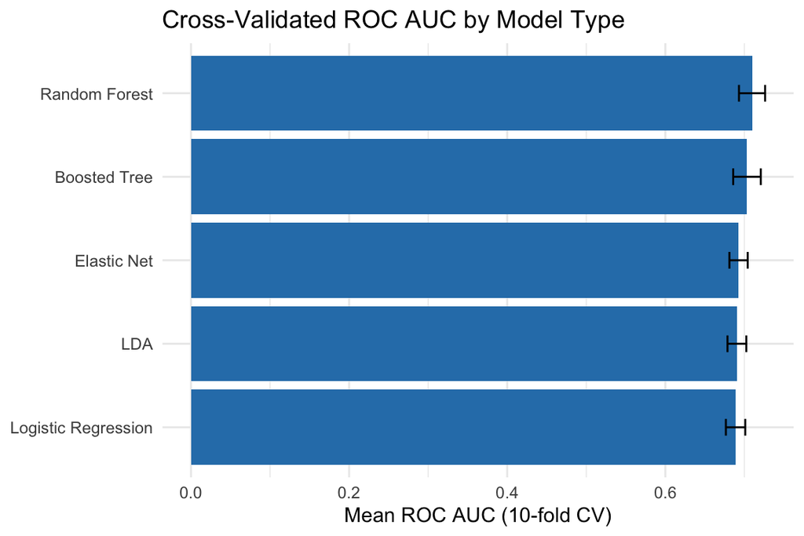

```r
ggplot(model_comparison, aes(x = fct_reorder(model, mean), y = mean)) +
  geom_col(fill = "#2c7fb8") +
  geom_errorbar(aes(ymin = mean - std_err, ymax = mean + std_err), width = 0.2) +
  coord_flip() +
  labs(title = "Cross-Validated ROC AUC by Model Type",
       x = NULL, y = "Mean ROC AUC (10-fold CV)") +
  theme_minimal()
```

```r
best_params <- select_best(rf_tune, metric = "roc_auc")
final_wflow <- finalize_workflow(rf_wflow, best_params)
final_fit   <- fit(final_wflow, data = ipo_train)
```

## Variable importance

```r
vi_scores <- final_fit %>% extract_fit_parsnip() %>% vip::vi()
vi_scores
```

```
##                         Variable Importance
## 1                year_difference 168.177116
## 2              market_year_trend 156.215735
## 3             market_month_trend 156.059352
## 4            market_6month_trend 155.305971
## 5            market_3month_trend 154.408607
## 6                 sector_unknown 112.765202
## 7                 sector_Finance  54.090141
## 8             sector_Health_Care  40.434050
## 9              sector_Technology  39.248443
## 10           usa_company_Unknown  36.856399
## 11     employees_grouped_Unknown  29.767780
## 12               usa_company_Yes  28.881169
## 13      sector_Consumer_Services  24.927741
## 14            ceo_gender_Unknown  21.820492
## 15      employees_grouped_X0_100  19.635881
## 16  employees_grouped_X1001_5000  19.632194
## 17          sector_Capital_Goods  18.774072
## 18    employees_grouped_X101_500  17.821426
## 19                 sector_Energy  17.215604
## 20               ceo_gender_male  16.733221
## 21   employees_grouped_X501_1000  16.444695
## 22 employees_grouped_X5001_10000  14.708082
## 23          sector_Miscellaneous  12.036199
## 24       sector_Public_Utilities  11.061256
## 25  sector_Consumer_Non_Durables   9.694471
## 26      sector_Consumer_Durables   9.330934
## 27         sector_Transportation   6.204274
## 28        ceo_gender_mostly_male   2.544780
## 29      ceo_gender_mostly_female   1.881637
```

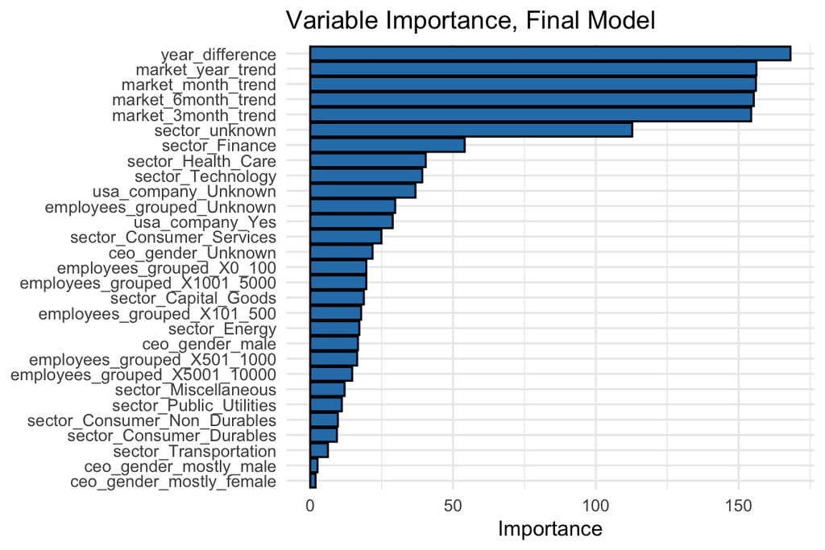

```r
ggplot(vi_scores, aes(x = fct_reorder(Variable, Importance), y = Importance)) +
  geom_col(fill = "#2c7fb8", color = "black") +
  coord_flip() +
  theme_minimal() +
  labs(title = "Variable Importance, Final Model", x = NULL)
```

# Performance on the Testing Set

```r
ipo_test_res <- augment(final_fit, new_data = ipo_test)

test_roc_auc <- roc_auc(ipo_test_res, truth = pop, .pred_Pop)
test_acc     <- accuracy(ipo_test_res, truth = pop, estimate = .pred_class)

bind_rows(test_roc_auc, test_acc)
```

```
## # A tibble: 2 × 3
##   .metric  .estimator .estimate
##   <chr>    <chr>          <dbl>
## 1 roc_auc  binary         0.696
## 2 accuracy binary         0.765
```

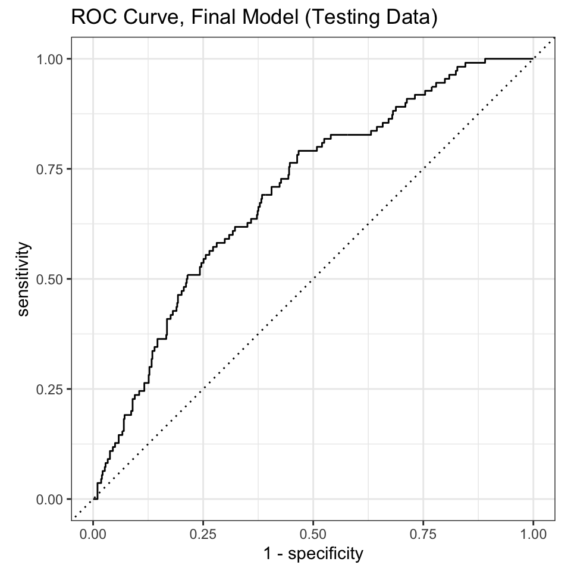

```r
roc_curve(ipo_test_res, truth = pop, .pred_Pop) %>%
  autoplot() +
  labs(title = "ROC Curve, Final Model (Testing Data)")
```

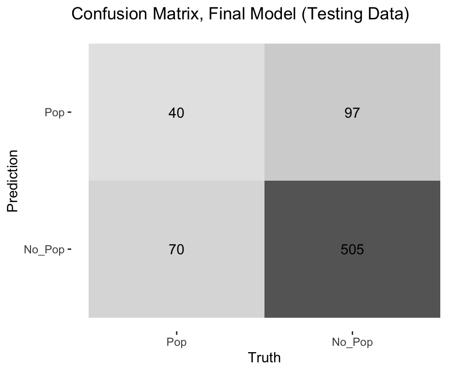

```r
conf_mat(ipo_test_res, truth = pop, estimate = .pred_class) %>%
  autoplot(type = "heatmap") +
  labs(title = "Confusion Matrix, Final Model (Testing Data)")
```

I compare `test_roc_auc` above to the mean cross-validated ROC AUC for the same model in `model_comparison`. If the two numbers are close together that’s good evidence the cross-validation actually gave an honest estimate of how the model generalizes. If the testing ROC AUC is noticeably lower, that suggests some overfitting to the training folds. If it’s noticeably higher, that’s most likely just because the testing set is relatively small, not because the model is actually better than what CV suggested.

# Conclusion

From the five models I fit, the cross-validated ROC AUC clustered pretty tightly in the 0.69-0.71 range no matter which model type I used. Random Forest ended up barely on top with a cross-validated ROC AUC of 0.710, just barely beating the boosted tree (0.703). The elastic net, LDA, and logistic regression were close behind at 0.693, 0.691, and 0.689. On the testing set, the final random forest scored a ROC AUC of 0.696 and an accuracy of 0.765 which is close to its 0.710 CV estimate. So cross-validation gave a pretty honest read on how the model would actually generalize. I think the fact that a simple logistic regression does almost as well as a tuned random forest is actually pretty interesting. It shows that the signal in this data is fairly linear and additive instead of being driven by complicated interactions between predictors. So the more flexible models don’t really have much of an advantage here.

The variable importance plot is actually pretty important here. `year_difference` and the four market-trend variables took the top five importance spots whcih were all clustered pretty close together roughly 154 to 168. `sector_unknown` which was basically whether sector was actually missing for a given IPO came in 6th place at 112.8 This was a real drop from the top five, but still way ahead of every actual named sector like employee-count bucket or CEO-gender category. This shows that market timing and company age matter the most but simply not having a sector on record for a company is still a surprisingly strong signal on its own. Lookibg back at the sector EDA plot, IPOs with an unrecorded sector only popped about 1% of the time compared to roughly 15% overall. So the “we don’t have this company’s basic info” is a genuinely strong signal by itself.This is probably because the same smaller abd lower-profile listings that never got fully documented are also the ones least likely to get investors as interested on release day which makes sense.

With this the model is definitely far from perfect which I don’t think that’s really surprising. Whether an IPO pops on its first day is driven by a lot of other uncalculated variables like investor sentiment, news about the similar stocks in the sector, and how the underwriters behave in the days leading up to the IPO. These numbers were not calculated in this dataset and can drive the IPO’s value. I think a model with a moderate but real ROC AUC is basically the expected outcome for a problem noisy modeling approach.

The class imbalance ended up mattering a lot here. My final model’s confusion matrix on the testing set caught 40 of the 110 real pops and missed 70.It also had 97 false positives giving an overall accuracy of 76.5%. That recall wouldn’t have happened without step_upsample() in the recipe with only about 15% of training rows labeled “Pop,” Upsampling forces the model to actually learn the minority class during training, which is exactly why I leaned on ROC AUC and not accuracy to pick the model in the first place.

In the future I think the best steps would be adding more features instead of trying even more model types. The raw file actually has hundreds of pre-IPO financial-statement line items like revenue, net income, total assets and more that I left out here because they’re extremely specific to certain industries. Building a version of this model around just a handful of these especially total revenue and net income the year before IPO would be the next thing to try. I also think fitting the model to more specfic sectors which would make these predictors more useful. Also training the model for more specfic IPO’s like health would make these models more accurate.

In conclusion, calculating if an IPO would “pop” or not is a very hard thing to model since it is so noisy. If it was this easy to calculate every big prop firm would do it. I think this was a very interesting project to do really showing how much goes into predicting stock direction which is why big firms pay so much and why quants make so much. In the end it was a fun model to train even though the recall rate was only 36.4% and 29.2% precision with a ROC of ~0.7, which wouldn’t be actually used to find if an IPO would “pop” or not.